[Oper Frankfurt](https://oper-frankfurt.de/de)

2022/23

# Spielplan

[zur Übersicht](https://oper-frankfurt.de/de/spielplan/)

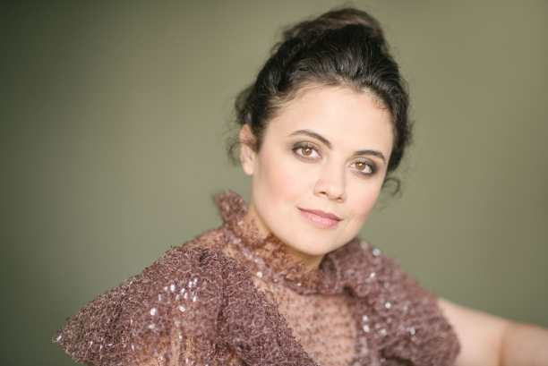

Katharina Konradi  
© Simon Pauly

## Katharina Konradi (Sopran) Ammiel Bushakevitz (Klavier)

Spätestens seit ihrem Auftritt als Sophie in Barrie Koskys *Rosenkavalier*-Inszenierung an der Bayerischen Staatsoper ist der jungen kirgisischen, in Berlin und München ausgebildeten Sängerin die Aufmerksamkeit der Opernwelt gewiss. Seit 2018 gehört sie zum Ensemble der Hamburgischen Staatsoper, wo sie u.a. als Ännchen, Zerlina, Susanna und Pamina überzeugte. An der Semperoper in Dresden sang sie die Zdenka und übernahm bei den Bayreuther Festspielen die Rolle des Hirten in Tobias Kratzers *Tannhäuser*-Inszenierung. Auch auf dem Konzertpodium hat sie sich einen Namen gemacht, u.a. mit dem Brahms-Requiem sowie als Liedsängerin z.B. bei der Schubertiade Schwarzenberg und in der Londoner Wigmore Hall. Begleitet von Ammiel Bushakevitz, der hier bereits gemeinsam mit Konstantin Krimmel und Anna Lucia Richter zu erleben war, präsentiert Katharina Konradi nun ihren ersten Liederabend an der Oper Frankfurt. Dabei treten Werke von Mozart und Schubert in einen Dialog mit Kompositionen des Ehepaares Clara und Robert Schumann.

Im Rahmen des Festivals

Apr 2023

Di25.

[Tickets](https://oper-frankfurt.eventim-inhouse.de/webshop/webticket/shop?event=12340&languages=de)

## Ihre Auswahl

**Dienstag**

25. April 2023

**Beginn**

19.30 Uhr

**Ort**

Opernhaus

**Abonnement**

Serie 18

**Preise**

B

## Besetzung

**Sopran**

Katharina Konradi

**Klavier, Gitarre**

[Ammiel Bushakevitz](https://oper-frankfurt.de/de/ensemble-gaeste-teams/ensemble/?detail=1131)